# survival power exploration

Eamonn O’Brien

27 September, 2021

We first show how to calculate at a specified time, changes in mortality % and hazards assuming an exponential distribution. The second graph we show how to calculate the change in time based on percentage increase in time for specified survival rate, again based on exponential distribution.

# 1 Two self written functions just plots to gain understanding, they do not use follow up nor accrual time.

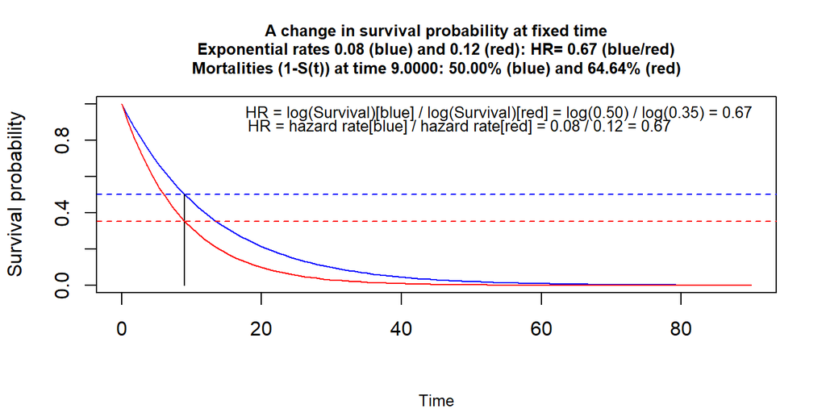

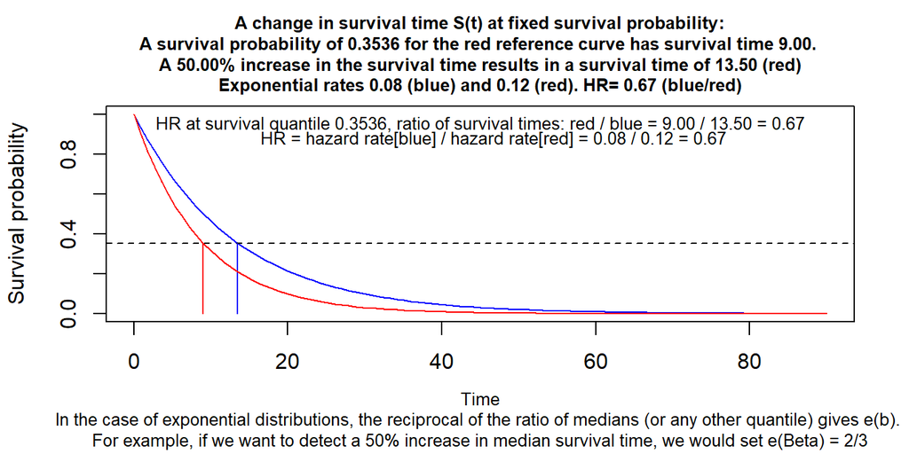

```r
    library(survival)
    library(rms) # for modelling
    library(tidyverse)
```